# Bike_Sharing_Google_Analytics

## Problem introduction

### About the company

In 2016, *Cyclistic* launched a successful bike-share oﬀering. Since then, the program has grown to a ﬂeet of 5,824 bicycles that are geotracked and locked into a network of 692 stations across Chicago. The bikes can be unlocked from one station and returned to any other station in the system anytime.

Until now, *Cyclistic*’s marketing strategy relied on building general awareness and appealing to broad consumer segments. One approach that helped make these things possible was the ﬂexibility of its pricing plans: single-ride passes, full-day passes, and annual memberships. Customers who purchase single-ride or full-day passes are referred to as casual riders. Customers who purchase annual memberships are *Cyclistic* members.

### How to achive company’s goal

*Cyclistic*’s ﬁnance analysts have concluded that annual members are much more proﬁtable than casual riders. Although the pricing ﬂexibility helps *Cyclistic* attract more customers, Moreno believes that maximizing the number of annual members will be key to future growth. Rather than creating a marketing campaign that targets all-new customers, Moreno believes there is a very good chance to convert casual riders into members. She notes that casual riders are already aware of the *Cyclistic* program and have chosen *Cyclistic* for their mobility needs.

Moreno has set a clear goal: Design marketing strategies aimed at converting casual riders into annual members. In order to do that, however, the marketing analyst team needs to better understand **how annual members and casual riders diﬀer**, **why casual riders would buy a membership**, and **how digital media could aﬀect their marketing tactics**. Moreno and her team are interested in analyzing the Cyclistic historical bike trip data to identify trends.

### Phase 1: Bring out the problems

##### Make questions to find the goal of stakeholders

As I am working on course number 8 [Google Data Analytics Capstone: Complete a Case Study](https://www.coursera.org/learn/google-data-analytics-capstone), I would complete the first part of the project:

- Find out the difference between membership and casual riders.
- Bring out some recommendations of how to create an effective campaign, and who the company needs to focus on, and key points regarding the processed data.

### Phase 2: Preparation

##### I prefer to using **R-Studio** & **Rmarkdown packages** in this project because of large amount of data.

#### Setting up my environment & packages

```r
library(tidyverse)
library(lubridate)
library(DescTools)
```

#### Import data from CSV file downloaded from [divvybikes.com](https://www.divvybikes.com/)

`tripdata_202003 <- read_csv("2020010203-divvy-tripdata.csv")` `tripdata_202004 <- read_csv("202004-divvy-tripdata.csv")` `tripdata_202005 <- read_csv("202005-divvy-tripdata.csv")` `tripdata_202006 <- read_csv("202006-divvy-tripdata.csv")` `tripdata_202007 <- read_csv("202007-divvy-tripdata.csv")` `tripdata_202008 <- read_csv("202008-divvy-tripdata.csv")` `tripdata_202009 <- read_csv("202009-divvy-tripdata.csv")` `tripdata_202010 <- read_csv("202010-divvy-tripdata.csv")` `tripdata_202011 <- read_csv("202011-divvy-tripdata.csv")` `tripdata_202012 <- read_csv("202012-divvy-tripdata.csv")` `tripdata_202101 <- read_csv("202101-divvy-tripdata.csv")` `tripdata_202102 <- read_csv("202102-divvy-tripdata.csv")` `tripdata_202103 <- read_csv("202103-divvy-tripdata.csv")` `tripdata_202104 <- read_csv("202104-divvy-tripdata.csv")` `tripdata_202105 <- read_csv("202105-divvy-tripdata.csv")` `tripdata_202106 <- read_csv("202106-divvy-tripdata.csv")` `tripdata_202107 <- read_csv("202107-divvy-tripdata.csv")` `tripdata_202108 <- read_csv("202108-divvy-tripdata.csv")`

#### Combine all datasets using `rbind()`

`tripdata <- rbind(tripdata_202003,` `tripdata_202004,` `tripdata_202005,` `tripdata_202006,` `tripdata_202007,` `tripdata_202008,` `tripdata_202009,` `tripdata_202010,` `tripdata_202011,` `tripdata_202012,` `tripdata_202101,` `tripdata_202102,` `tripdata_202103,` `tripdata_202104,` `tripdata_202105,` `tripdata_202106,` `tripdata_202107,` `tripdata_202108)`

#### Get a big picture of the dataset using `glimpse()` and `str()`

```r
glimpse(tripdata)
```

```
## Rows: 7,141,855
## Columns: 13
## $ ride_id            <chr> "EACB19130B0CDA4A", "8FED874C809DC021", "789F3C21E4~
## $ rideable_type      <chr> "docked_bike", "docked_bike", "docked_bike", "docke~
## $ started_at         <dttm> 2020-01-21 20:06:59, 2020-01-30 14:22:39, 2020-01-~
## $ ended_at           <dttm> 2020-01-21 20:14:30, 2020-01-30 14:26:22, 2020-01-~
## $ start_station_name <chr> "Western Ave & Leland Ave", "Clark St & Montrose Av~
## $ start_station_id   <chr> "239", "234", "296", "51", "66", "212", "96", "96",~
## $ end_station_name   <chr> "Clark St & Leland Ave", "Southport Ave & Irving Pa~
## $ end_station_id     <chr> "326", "318", "117", "24", "212", "96", "212", "212~
## $ start_lat          <dbl> 41.9665, 41.9616, 41.9401, 41.8846, 41.8856, 41.889~
## $ start_lng          <dbl> -87.6884, -87.6660, -87.6455, -87.6319, -87.6418, -~
## $ end_lat            <dbl> 41.9671, 41.9542, 41.9402, 41.8918, 41.8899, 41.884~
## $ end_lng            <dbl> -87.6674, -87.6644, -87.6530, -87.6206, -87.6343, -~
## $ member_casual      <chr> "member", "member", "member", "member", "member", "~
```

```r
str(tripdata)
```

```
## spec_tbl_df [7,141,855 x 13] (S3: spec_tbl_df/tbl_df/tbl/data.frame)
##  $ ride_id           : chr [1:7141855] "EACB19130B0CDA4A" "8FED874C809DC021" "789F3C21E472CA96" "C9A388DAC6ABF313" ...
##  $ rideable_type     : chr [1:7141855] "docked_bike" "docked_bike" "docked_bike" "docked_bike" ...
##  $ started_at        : POSIXct[1:7141855], format: "2020-01-21 20:06:59" "2020-01-30 14:22:39" ...
##  $ ended_at          : POSIXct[1:7141855], format: "2020-01-21 20:14:30" "2020-01-30 14:26:22" ...
##  $ start_station_name: chr [1:7141855] "Western Ave & Leland Ave" "Clark St & Montrose Ave" "Broadway & Belmont Ave" "Clark St & Randolph St" ...
##  $ start_station_id  : chr [1:7141855] "239" "234" "296" "51" ...
##  $ end_station_name  : chr [1:7141855] "Clark St & Leland Ave" "Southport Ave & Irving Park Rd" "Wilton Ave & Belmont Ave" "Fairbanks Ct & Grand Ave" ...
##  $ end_station_id    : chr [1:7141855] "326" "318" "117" "24" ...
##  $ start_lat         : num [1:7141855] 42 42 41.9 41.9 41.9 ...
##  $ start_lng         : num [1:7141855] -87.7 -87.7 -87.6 -87.6 -87.6 ...
##  $ end_lat           : num [1:7141855] 42 42 41.9 41.9 41.9 ...
##  $ end_lng           : num [1:7141855] -87.7 -87.7 -87.7 -87.6 -87.6 ...
##  $ member_casual     : chr [1:7141855] "member" "member" "member" "member" ...
##  - attr(*, "spec")=
##   .. cols(
##   ..   ride_id = col_character(),
##   ..   rideable_type = col_character(),
##   ..   started_at = col_datetime(format = ""),
##   ..   ended_at = col_datetime(format = ""),
##   ..   start_station_name = col_character(),
##   ..   start_station_id = col_double(),
##   ..   end_station_name = col_character(),
##   ..   end_station_id = col_double(),
##   ..   start_lat = col_double(),
##   ..   start_lng = col_double(),
##   ..   end_lat = col_double(),
##   ..   end_lng = col_double(),
##   ..   member_casual = col_character()
##   .. )
##  - attr(*, "problems")=<externalptr>
```

We have total *13 variables* and *7,141,855 observations*

### Phase 3: Process

##### Find & remove missing values in the datasets then filter the invalid data.

#### Remove rows with missing values

```r
colSums(is.na(tripdata))
```

```
##            ride_id      rideable_type         started_at           ended_at
##                  0                  0                  0                  0
## start_station_name   start_station_id   end_station_name     end_station_id
##             457789             458414             503271             503732
##          start_lat          start_lng            end_lat            end_lng
##                  0                  0               7612               7612
##      member_casual
##                  0
```

#### Data with missing values will be removed

```r
tripdata_cleaned <- tripdata[complete.cases(tripdata), ]
```

#### Data with started_at greater than ended_at will be removed

```r
tripdata_cleaned <- tripdata_cleaned %>%
  filter(tripdata_cleaned$started_at < tripdata_cleaned$ended_at)
```

### Phase 4: Analyze the final dataset

##### Make new variable used to distinguish the casual and membership riders

#### Create new column `ride_length`

```r
tripdata_cleaned$ride_length <- tripdata_cleaned$ended_at - tripdata_cleaned$started_at
tripdata_cleaned$ride_length <- hms::hms(seconds_to_period(tripdata_cleaned$ride_length))
```

#### Create new column `day_of_week`

```r
tripdata_cleaned$day_of_week <- wday(tripdata_cleaned$started_at, label = FALSE)
```

#### Overall points of data

##### Mean of ride_length

```r
tripdata_cleaned %>%
  summarize(mean(ride_length))
```

```
## # A tibble: 1 x 1
##   `mean(ride_length)`
##   <drtn>
## 1 1563.743 secs
```

##### Max ride_length

```r
tripdata_cleaned %>%
  summarize(max(ride_length))
```

```
## # A tibble: 1 x 1
##   `max(ride_length)`
##   <drtn>
## 1 9387024 secs
```

##### Min ride_length

```r
tripdata_cleaned %>%
  summarize(min(ride_length))
```

```
## # A tibble: 1 x 1
##   `min(ride_length)`
##   <drtn>
## 1 1 secs
```

##### Mode of day_of_week

```r
Mode(tripdata_cleaned$day_of_week)
```

```
## [1] 7
## attr(,"freq")
## [1] 1162326
```

##### Average ride_length for members and casual riders

```r
tripdata_cleaned %>%
  group_by(member_casual) %>%
  summarize(mean(ride_length))
```

```
## # A tibble: 2 x 2
##   member_casual `mean(ride_length)`
##   <chr>         <drtn>
## 1 casual        2464.7355 secs
## 2 member         892.0576 secs
```

##### Average ride_length for users by day_of_week

```r
tripdata_cleaned %>%
  group_by(day_of_week) %>%
  summarize(mean(ride_length))
```

```
## # A tibble: 7 x 2
##   day_of_week `mean(ride_length)`
##         <dbl> <drtn>
## 1           1 1976.310 secs
## 2           2 1432.317 secs
## 3           3 1304.232 secs
## 4           4 1316.909 secs
## 5           5 1375.488 secs
## 6           6 1499.300 secs
## 7           7 1856.468 secs
```

##### Number of rides for users by day_of_week

```r
tripdata_cleaned %>%
  group_by(day_of_week) %>%
  summarize(number_of_rides = n())
```

```
## # A tibble: 7 x 2
##   day_of_week number_of_rides
##         <dbl>           <int>
## 1           1          997552
## 2           2          800638
## 3           3          833704
## 4           4          847464
## 5           5          851736
## 6           6          941815
## 7           7         1162326
```

##### Average ride time by each day for members vs casual users

```r
aggregate(tripdata_cleaned$ride_length ~ tripdata_cleaned$member_casual + tripdata_cleaned$day_of_week, FUN = mean)
```

```
##    tripdata_cleaned$member_casual tripdata_cleaned$day_of_week
## 1                          casual                            1
## 2                          member                            1
## 3                          casual                            2
## 4                          member                            2
## 5                          casual                            3
## 6                          member                            3
## 7                          casual                            4
## 8                          member                            4
## 9                          casual                            5
## 10                         member                            5
## 11                         casual                            6
## 12                         member                            6
## 13                         casual                            7
## 14                         member                            7
##    tripdata_cleaned$ride_length
## 1                2800.4232 secs
## 2                1029.3105 secs
## 3                2410.3052 secs
## 4                 851.7786 secs
## 5                2204.7068 secs
## 6                 830.5304 secs
## 7                2222.2634 secs
## 8                 838.8218 secs
## 9                2326.9023 secs
## 10                836.6676 secs
## 11               2362.7948 secs
## 12                870.5208 secs
## 13               2568.9239 secs
## 14               1008.0213 secs
```

##### Analyze ridership data by type and weekday

```r
ridership_type_weekday <- tripdata_cleaned %>%
  mutate(weekday = wday(started_at, label = TRUE)) %>%
  group_by(member_casual, weekday) %>%
  summarize(number_of_rides = n(),
            average_duration = mean(ride_length)) %>%
  arrange(member_casual, weekday)
```

### Phase 5: Sharing ideas

##### Make visualization based on the findings of dataset with `ggplot()`

#### Visualize number of rides by rider type

```r
tripdata_cleaned_v2 <- tripdata_cleaned %>%
  mutate(weekday = wday(started_at, label = TRUE)) %>%
  group_by(member_casual, weekday) %>%
  summarize(number_of_rides = n(),
            average_duration = mean(ride_length)) %>%
  arrange(member_casual, weekday)
```

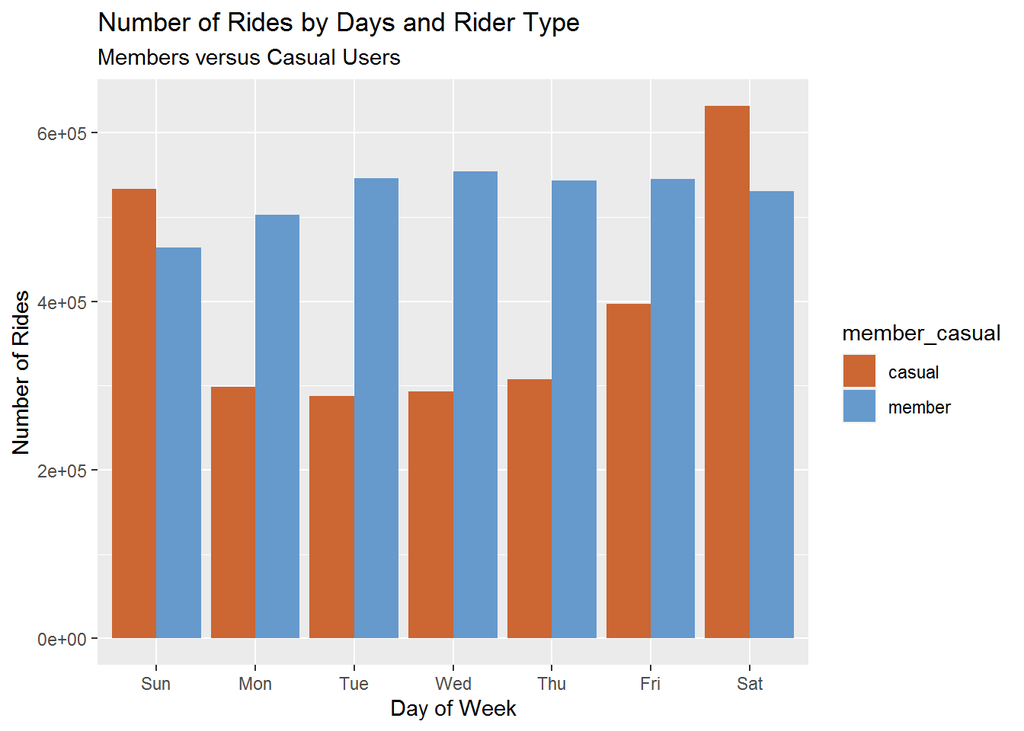

```r
  p <- ggplot(data = tripdata_cleaned_v2, aes(x = weekday, y = number_of_rides, fill = member_casual)) +
  geom_col(position = "dodge") +
  scale_fill_manual(values = c("#CC6633","#6699CC")) +
  labs(title = "Number of Rides by Days and Rider Type",
       subtitle = "Members versus Casual Users") +
  ylab("Number of Rides") +
  xlab("Day of Week")
p
```

#### Visualization for average duration

```r
tripdata_cleaned_v3 <- tripdata_cleaned %>%
  mutate(weekday = wday(started_at, label = TRUE)) %>%
  group_by(member_casual, weekday) %>%
  summarize(average_duration = mean(ride_length)) %>%
  arrange(member_casual, weekday)
```

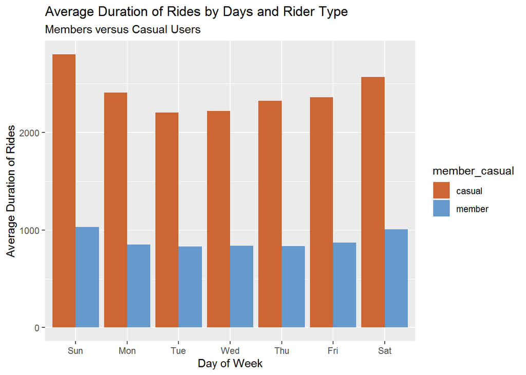

```r
  p1 <- ggplot(data = tripdata_cleaned_v3, aes(x = weekday, y = average_duration, fill = member_casual)) +
  geom_col(position = "dodge") +
  scale_fill_manual(values = c("#CC6633","#6699CC")) +
  labs(title = "Average Duration of Rides by Days and Rider Type",
       subtitle = "Members versus Casual Users") +
  ylab("Average Duration of Rides") +
  xlab("Day of Week")
p1
```

#### Average ride_length by type and day of week

```r
counts <- aggregate(tripdata_cleaned$ride_length ~ tripdata_cleaned$member_casual +
                      tripdata_cleaned$day_of_week, FUN = mean)
glimpse(counts)
```

```
## Rows: 14
## Columns: 3
## $ `tripdata_cleaned$member_casual` <chr> "casual", "member", "casual", "member~
## $ `tripdata_cleaned$day_of_week`   <dbl> 1, 1, 2, 2, 3, 3, 4, 4, 5, 5, 6, 6, 7~
## $ `tripdata_cleaned$ride_length`   <drtn> 2800.4232 secs, 1029.3105 secs, 2410~
```

#### Average ride_length and type and month

```r
tripdata_cleaned$month <- month(tripdata_cleaned$started_at, label = TRUE)
rides <- aggregate(tripdata_cleaned$ride_length ~ tripdata_cleaned$member_casual +
                     tripdata_cleaned$month,FUN = mean)
write.csv(rides, file = 'avg_ride_length_by_month.csv')
```

#### Create output file to use on Tableau

`all_trips <- tripdata_cleaned %>%` `select(-day_of_week)` `all_trips$day_of_week <- wday(all_trips$started_at, label = TRUE)` `write.csv(all_trips, file = "all_trips.csv", row.names = FALSE)` `write.csv(counts, file = 'avg_ride-length.csv')`

## Key take-aways

- The number of rides of casual riders is larger than ones of membership members in the weekend.As a result, the marketing campaigns should focus on the casual riders in the weekend.
- The average length per ride of casual riders are doubled one of membership riders. The company should use some promotions to attract membership from casual riders.